# Table of Contents

$$\require{color} \require{cancel} \def\tf#1{{\mathrm{FT}\left\{ #1 \right\}}} \def\flecheTF{\rightleftharpoons } \def\TFI#1#2#3{{\displaystyle{\int_{-\infty}^{+\infty} #1 ~e^{j2\pi #2 #3} ~\dr{#2}}}} \def\TF#1#2#3{{\displaystyle{\int_{-\infty}^{+\infty} #1 ~e^{-j2\pi #3 #2} ~\dr{#2}}}} \def\sha{ш} \def\dr#1{\mathrm{d}#1} \def\egalpardef{\mathop{=}\limits^\triangle} \def\sinc#1{{\mathrm{sinc}\left( #1 \right)}} \def\rect{\mathrm{rect}} \definecolor{lightred}{rgb}{1,0.1,0} \def\myblueeqbox#1{{\fcolorbox{blue}{lightblue}{$ extcolor{blue}{ #1}$}}} \def\myeqbox#1#2{{\fcolorbox{#1}{light#1}{$ extcolor{#1}{ #2}$}}} \def\eqbox#1#2#3#4{{\fcolorbox{#1}{#2}{$\textcolor{#3}{ #4}$}}} % border|background|text \def\eqboxa#1{{\boxed{#1}}} \def\eqboxb#1{{\eqbox{green}{white}{green}{#1}}} \def\eqboxc#1{{\eqbox{blue}{white}{blue}{#1}}} \def\eqboxd#1{{\eqbox{blue}{lightblue}{blue}{#1}}} \def\E#1{\mathbb{E}\left[#1\right]} \def\ta#1{\left<#1\right>} \def\egalparerg{{\mathop{=}\limits_\mathrm{erg}}} \def\expo#1{\exp\left(#1\right)} \def\d#1{\mathrm{d}#1} \def\wb{\mathbf{w}} \def\sb{\mathbf{s}} \def\xb{\mathbf{x}} \def\Rb{\mathbf{R}} \def\rb{\mathbf{r}} \def\mystar{{*}} \def\ub{\mathbf{u}} \def\wbopt{\mathop{\mathbf{w}}\limits^\triangle} \def\deriv#1#2{\frac{\mathrm{d}#1}{\mathrm{d}#2}} \def\Ub{\mathbf{U}} \def\db{\mathbf{d}} \def\eb{\mathbf{e}} \def\vb{\mathbf{v}} \def\Ib{\mathbf{I}} \def\Vb{\mathbf{V}} \def\Lambdab{\mathbf{\Lambda}} \def\Ab{\mathbf{A}} \def\Bb{\mathbf{B}} \def\Cb{\mathbf{C}} \def\Db{\mathbf{D}} \def\Kb{\mathbf{K}} \def\sinc#1{\mathrm{sinc\left(#1\right)}} $$

```python
from scipy.signal import lfilter
from scipy.fftpack import fft, ifft
%matplotlib inline
```

## Filtering

### General relations for cross-correlations

We consider a situation where we want to study the correlations between the different inputs and outputs of a pair of two filters: $$ \left{

\begin{array}{lcr} Y_1(n,\omega) & = & (X_1*h_1)(n,\omega),\\ Y_2(n,\omega) & = & (X_2*h_2)(n,\omega), \end{array}

\right. $$

[figure not shown]

Let us compute the intercorrelation between $Y_1(n)$ and $Y_2(n)$ : $$ R_{Y_1Y_2}(m) = \E{Y_1(n,\omega)Y_2^*(n-m,\omega))} = \E{(X_1*h_1)(n,\omega))(X_2^* *h_2^*)(n-m,\omega))}. $$ The two convolution products are \begin{eqnarray*} (X_1*h_1)(n,\omega)) & = & \sum_u X_1(u,\omega))h_1(n-u),\\ (X_2*h_2)(n-m,\omega))& = & \sum_v X_2(v,\omega))h_2(n-m-v), \end{eqnarray*} and \begin{eqnarray*} R_{Y_1Y_2}(m) & = & \E{\sum_u X_1(n-u,\omega))h_1(u)\sum_v X_2^*(n-m-v,\omega))h_2^*(v)}\\ & = & \E{\sum_u \sum_v X_1(n-u)h_1(u) X_2^*(n-m-v)h_2^*(v)}\\ & = & \sum_u \sum_v h_1(u) R_{X_1X_2}(m+v-u) h_2^*(v). \end{eqnarray*} Looking at the sum over $u$, we recognize a convolution product between $h_1$ and $R_{X_1X_2}$, expressed at time $(m+v)$ : \begin{eqnarray*} R_{Y_1Y_2}(m) & = & \sum_v (h_1 * R_{X_1X_2})(m+v) h_2^*(v)\\ & = & \sum_v (h_1 * R_{X_1X_2})(m+v) h_2^{(-)*}(-v), \end{eqnarray*} where we have noted $h_2^{(-)}(v) = h_2(-v)$. In this last relation, we recognize anoter convolution product, this time between $(h_1 * R_{X_1X_2})$ and $h_2^{*(-)}$ : \begin{eqnarray*} R_{Y_1Y_2}(m) & = & \sum_v (h_1 * R_{X_1X_2})(m+v) h_2^{*(-)}(-v)\\ & = & \sum_{v'}(h_1 * R_{X_1X_2})(m-v') h_2^{*(-)}(v') \\ & = & \left( h_1 * R_{X_1X_2} * h_2^{*(-)} \right) (m). \end{eqnarray*}

We finally obtain the important formula: $$ \eqboxc{R_{Y_1Y_2}(m) = \left( h_1 * R_{X_1X_2} * h_2^{*(-)}\right) (m)}. $$

### By-products

- **[Autocorrelation of the output of a filter]** With a single filter we can apply the previous formula, with $$ \left{

\begin{array}{l} X_1=X_2=X, \\ h_1=h_2=h. \end{array}

- **[Cross correlation between output and input]** We want to measure the correlation between the input and output of a filter. Toward this goal, we consider $$ \left{

### Examples

> We study now the filtering of random signals. We begin with the classical impulse response $h(n) = a^n$, with $x(n)$ a uniform distributed white noise at the input, and we denote $y(n)$ the output.
> 1. Filter the signal $x(n)$, with the help of the function `lfilter`. Compare the input and output signals, and in particular their variations. Compare the histograms. Look at the Fourier transform of the output. Do this for several values of $a$, beginning with $a=0.9$.
> 2. Using the function `xcorr` (import it via `from correlation import xcorr`), compute all the possible correlations between the input and the output. What would be the correlation matrix associated with the signal $x(n) = [x(n)~ y(n)]^t$? Compare the impulse response $h$ to the cross-correlation $Ryx(k)$. Explain. Experiment by varying the number of samples $N$ and $a$ (including its sign).
> 3. Consider the identification of the impulse response by cross-correlation, as above, but in the noisy case. Add a Gaussian noise to the output and compute the cross-correlation. Observe, comment and experiment with the parameters.

The filtering is done thanks to the function `lfilter`. We have first to import it, *eg* as

```
 from scipy.signal import lfilter
```

```
 from scipy.fft import fft, ifft
```

```python
N = 1000  #Number of samples
x = stats.uniform(-0.5, 1).rvs(N)
a = 0.9
# Filtering and plots...
# FILL IN...
```

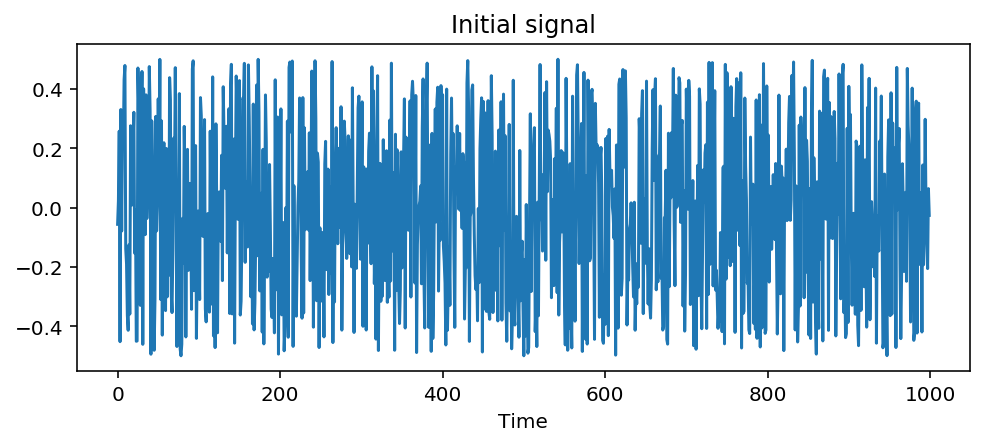

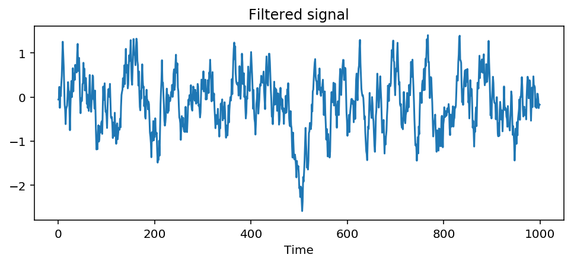

```python
y = lfilter([1], [1, -a], x)
figure(figsize=(8, 3))
plot(x)
xlabel("Time")
title("Initial signal")
figure(figsize=(8, 3))
plot(y)
xlabel("Time")
title("Filtered signal")
```

We see that the output has slower variations than the input. This is the result of the filtering operation. Let us now look at the histograms:

```python
#Histograms
# FILL IN
```

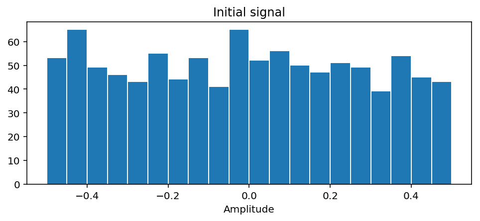

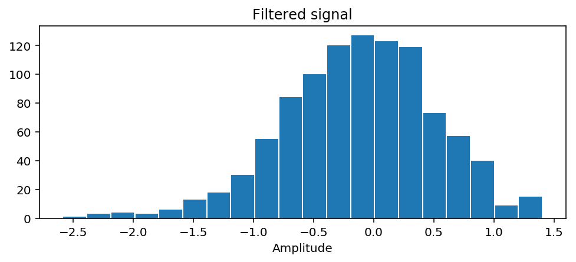

```python
# Histograms
figure(figsize=(8, 3))
plt.hist(x, bins=20, rwidth=0.95)
plt.xlabel("Amplitude")
plt.title("Initial signal")
figure(figsize=(8, 3))
plt.hist(y, bins=20, rwidth=0.95)
plt.xlabel("Amplitude")
plt.title("Filtered signal")
```

While the initial signal is uniformly distributed, the histogram of the output looks like the histogram of a gaussian. Actually, this is related to the central limit theorem: the mixture of iid variables tends to a gaussian. This also explains th emodification of the amplitudes observed on the time signal.

Let us finally look at the Fourier transform:

```python
#FILL IN
```

```
(-0.54995, 0.54895, -7.625895183114649, 167.46236056577)
```

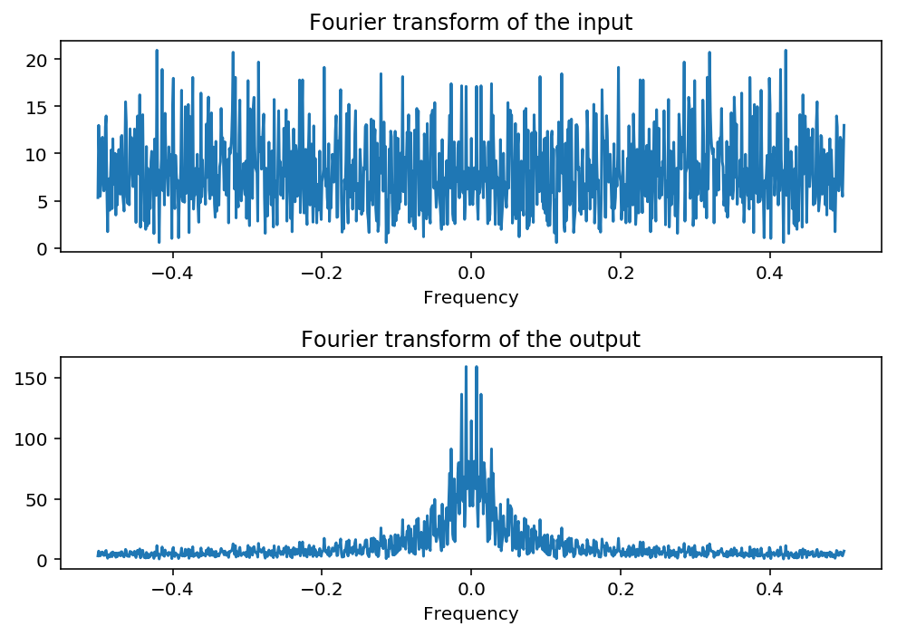

```python
f = arange(N) / N - 0.5
fig, ax = subplots(2, 1, figsize=(7, 5))
ax[0].plot(f, abs(fftshift(fft(x))))
ax[0].set_title("Fourier transform of the input")
ax[0].set_xlabel("Frequency")
ax[0].axis('tight')  #Tight layout of the axis
ax[1].plot(f, abs(fftshift(fft(y))))
ax[1].set_title("Fourier transform of the output")
ax[1].set_xlabel("Frequency")
fig.tight_layout()
ax[1].axis('tight')
```

Recall how the transfer function changes with $a$:

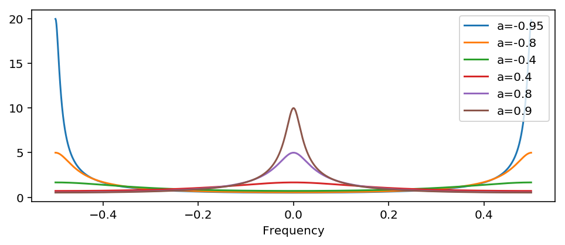

```python
figure(figsize=(8, 3))
d = zeros(N)
d[0] = 1
for a in (-0.95, -0.8, -0.4, 0.4, 0.8, 0.9):
    h = lfilter([1], [1, -a], d)
    H = fft(h)
    plot(f, abs(fftshift(H)), label='a={}'.format(a))

legend()
axis('tight')
_ = xlabel("Frequency")
```

### Correlation matrix

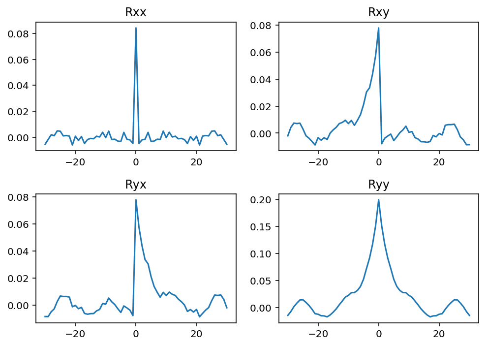

```python
from correlation import xcorr
N = 1000  #Number of samples
x = stats.uniform(-0.5, 1).rvs(N)
a = 0.8
y = lfilter([1], [1, -a], x)

L = 30
Rxx, lags = xcorr(x, x, maxlags=L)
Rxy, lags = xcorr(x, y, maxlags=L)
Ryx, lags = xcorr(y, x, maxlags=L)
Ryy, lags = xcorr(y, y, maxlags=L)
fig, ax = subplots(2, 2, figsize=(7, 5))
axf = ax.flatten()
Rtitles = ('Rxx', 'Rxy', 'Ryx', 'Ryy')
for k, z in enumerate((Rxx, Rxy, Ryx, Ryy)):
    axf[k].plot(lags, z)
    axf[k].set_title(Rtitles[k])
fig.tight_layout()
```

We have represented above all the possible correlations between the input and the ouput. This representation corresponds to the correlation matrix of the vector $z(n)=[x(n) ~~ y(n)]^H$ that would give $$ \mathbb{E}\left\{ \left[ \begin{array}[c]{c} x(n)\\ y(n) \end{array}\right]\left[ \begin{array}[c]{cc} x(n-k)^{*} & y(n-k)^{*}\end{array}\right]\right\} =\left[ \begin{array}[c]{cc} R_{xx}(k) & R_{xy}(k)\\ R_{yx}(k) & R_{yy}(k) \end{array}\right] $$

### Identification of a filter by cross-correlation

We know that the cross-correlation of the output of a system with IR $h$ with its input is given by $$ R_{yx}(k)=\left(R_{xx}*h\right)(k). $$ When the input is a white noise, then its autocorrelation $R_{xx}(k)$ is a Dirac impulse with weight $\sigma_x^2$, $R_{xx}(k)=\sigma_x^2\delta(k)$, and $R_{yx}$ is proportional to the impulse response: $$ R_{yx}(k)=\sigma_x^2 h(k). $$ This is what we observe here:

```
Uniform distribution:  Value of the mean : 0.500 and of the variance 0.083
```

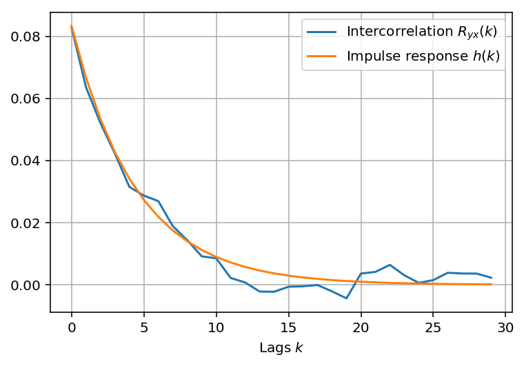

```python
# An object "uniform random variable" with fixed bounds [0,1]
from correlation import xcorr
x_uni = stats.uniform(loc=0, scale=1)
(m, v) = x_uni.stats(moments='mv')
print("Uniform distribution: ",
      "Value of the mean : {0:2.3f} and of the variance {1:2.3f}".format(
          float(m), float(v)))
N = 1000  #Number of samples
x = stats.uniform(-0.5, 1).rvs(N)  #generates N values for x
a = 0.8
y = lfilter([1], [1, -a], x)  #Computes the output of the system
L = 30
Ryx, lags = xcorr(y, x, maxlags=L)  #then the cross-correlation
d = zeros(N)
d[0] = 1
h = lfilter([1], [1, -a], d)  #and the impulse response
plot(arange(L), Ryx[arange(L, L + L)], label="Intercorrelation $R_{yx}(k)$")
plot(arange(L), v * h[arange(L)], label="Impulse response $h(k)$")
xlabel("Lags $k$")
grid(True)
legend()
```

In the noisy case, the same kind of observations hold. Indeed, if $z$ is a corrupted version of $y$, with $z(n)=y(n)+w(n)$, then $$ R_{zx}(k)=R_{yx}(k)+R_{wx}(k)=R_{yx}(k) $$ provided that $x$ and $w$ are uncorrelated, which is reasonable assumption.

```python
N = 1000
#Remember that the variance of $x$ is given by
x_uni = stats.uniform(-0.5, 1)
(m, v) = x_uni.stats(moments='mv')
print("Uniform distribution: ",
      "Value of the mean : {0:2.3f} and of the variance {1:2.3f}".format(
          float(m), float(v)))
```

```
Uniform distribution:  Value of the mean : 0.000 and of the variance 0.083
```

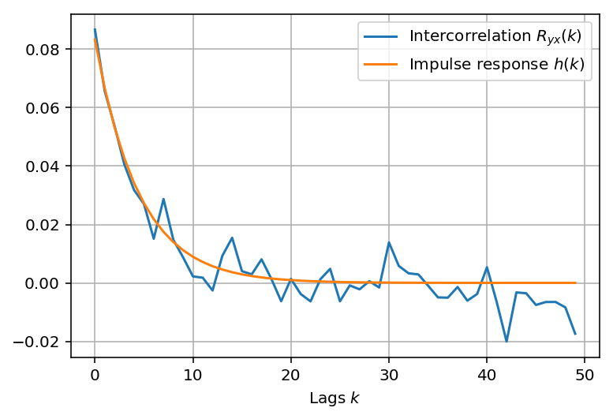

```python
N = 1000  #Number of samples
x = stats.uniform(-0.5, 1).rvs(N)  #generates N values for x
a = 0.8
y = lfilter([1], [1, -a], x)  #Computes the output of the system
w = stats.norm(0, 1).rvs(N)  #Gaussian noise
y = y + 0.5 * w
L = 50
Ryx, lags = xcorr(y, x, maxlags=L)  #then the cross-correlation
d = zeros(N)
d[0] = 1
h = lfilter([1], [1, -a], d)  #and the impulse response
plot(arange(L), Ryx[arange(L, L + L)], label="Intercorrelation $R_{yx}(k)$")
plot(arange(L), v * h[arange(L)], label="Impulse response $h(k)$")
xlabel("Lags $k$")
grid(True)
legend()
```

while the direct measure of the impulse response would give

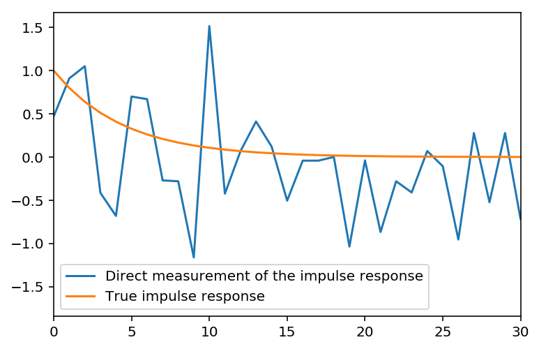

```python
plot(
    arange(N), h + 0.5 * w, label="Direct measurement of the impulse response")
plot(arange(N), h, label="True impulse response")
xlim([0, 30])
_ = legend()
```

Hence, we see that identification of a system is possible by cross-correlation, even when dealing with noisy outputs. Such identification would be impossible by direct measurement of the IR, because of the presence of noise.

[Jupyter notebook]